# Phan Thị Tường Vi - 22521658

```python
%matplotlib inline
import matplotlib.pyplot as plt
import numpy as np
import pandas as pd
import seaborn as sns

from sklearn.model_selection import train_test_split
from sklearn import tree
from sklearn.naive_bayes import GaussianNB
from sklearn import metrics
```

```python
train = pd.read_csv('adult.data.csv')
```

```python
test = pd.read_csv('adult.test.csv')
```

```python
test.replace(' ?', np.nan, inplace=True)
train.replace(' ?', np.nan, inplace=True)
```

```python
test=test.dropna()
test

train=train.dropna()
train
```

|  | age | workclass | fnlwgt | education | education-num | marital-status | occupation | relationship | race | sex | capital-gain | capital-loss | hours-per-week | native-country | income |
| --- | --- | --- | --- | --- | --- | --- | --- | --- | --- | --- | --- | --- | --- | --- | --- |
| 0 | 39 | State-gov | 77516 | Bachelors | 13 | Never-married | Adm-clerical | Not-in-family | White | Male | 2174 | 0 | 40 | United-States | <=50K |
| 1 | 50 | Self-emp-not-inc | 83311 | Bachelors | 13 | Married-civ-spouse | Exec-managerial | Husband | White | Male | 0 | 0 | 13 | United-States | <=50K |
| 2 | 38 | Private | 215646 | HS-grad | 9 | Divorced | Handlers-cleaners | Not-in-family | White | Male | 0 | 0 | 40 | United-States | <=50K |
| 3 | 53 | Private | 234721 | 11th | 7 | Married-civ-spouse | Handlers-cleaners | Husband | Black | Male | 0 | 0 | 40 | United-States | <=50K |
| 4 | 28 | Private | 338409 | Bachelors | 13 | Married-civ-spouse | Prof-specialty | Wife | Black | Female | 0 | 0 | 40 | Cuba | <=50K |
| ... | ... | ... | ... | ... | ... | ... | ... | ... | ... | ... | ... | ... | ... | ... | ... |
| 32556 | 27 | Private | 257302 | Assoc-acdm | 12 | Married-civ-spouse | Tech-support | Wife | White | Female | 0 | 0 | 38 | United-States | <=50K |
| 32557 | 40 | Private | 154374 | HS-grad | 9 | Married-civ-spouse | Machine-op-inspct | Husband | White | Male | 0 | 0 | 40 | United-States | >50K |
| 32558 | 58 | Private | 151910 | HS-grad | 9 | Widowed | Adm-clerical | Unmarried | White | Female | 0 | 0 | 40 | United-States | <=50K |
| 32559 | 22 | Private | 201490 | HS-grad | 9 | Never-married | Adm-clerical | Own-child | White | Male | 0 | 0 | 20 | United-States | <=50K |
| 32560 | 52 | Self-emp-inc | 287927 | HS-grad | 9 | Married-civ-spouse | Exec-managerial | Wife | White | Female | 15024 | 0 | 40 | United-States | >50K |

30162 rows × 15 columns

```python
del train["fnlwgt"]
```

```python
df=pd.concat([train,test])
```

```python
df
```

|  | age | workclass | education | education-num | marital-status | occupation | relationship | race | sex | capital-gain | capital-loss | hours-per-week | native-country | income |
| --- | --- | --- | --- | --- | --- | --- | --- | --- | --- | --- | --- | --- | --- | --- |
| 0 | 39 | State-gov | Bachelors | 13 | Never-married | Adm-clerical | Not-in-family | White | Male | 2174 | 0 | 40 | United-States | <=50K |
| 1 | 50 | Self-emp-not-inc | Bachelors | 13 | Married-civ-spouse | Exec-managerial | Husband | White | Male | 0 | 0 | 13 | United-States | <=50K |
| 2 | 38 | Private | HS-grad | 9 | Divorced | Handlers-cleaners | Not-in-family | White | Male | 0 | 0 | 40 | United-States | <=50K |
| 3 | 53 | Private | 11th | 7 | Married-civ-spouse | Handlers-cleaners | Husband | Black | Male | 0 | 0 | 40 | United-States | <=50K |
| 4 | 28 | Private | Bachelors | 13 | Married-civ-spouse | Prof-specialty | Wife | Black | Female | 0 | 0 | 40 | Cuba | <=50K |
| ... | ... | ... | ... | ... | ... | ... | ... | ... | ... | ... | ... | ... | ... | ... |
| 16275 | 33 | Private | Bachelors | 13 | Never-married | Prof-specialty | Own-child | White | Male | 0 | 0 | 40 | United-States | <=50K |
| 16276 | 39 | Private | Bachelors | 13 | Divorced | Prof-specialty | Not-in-family | White | Female | 0 | 0 | 36 | United-States | <=50K |
| 16278 | 38 | Private | Bachelors | 13 | Married-civ-spouse | Prof-specialty | Husband | White | Male | 0 | 0 | 50 | United-States | <=50K |
| 16279 | 44 | Private | Bachelors | 13 | Divorced | Adm-clerical | Own-child | Asian-Pac-Islander | Male | 5455 | 0 | 40 | United-States | <=50K |
| 16280 | 35 | Self-emp-inc | Bachelors | 13 | Married-civ-spouse | Exec-managerial | Husband | White | Male | 0 | 0 | 60 | United-States | >50K |

45222 rows × 14 columns

```python
print('Number of training data :', len(train))
```

```
Number of training data : 30162
```

```python
print('Number of test data :', len(test))
```

```
Number of test data : 15060
```

### Cau4

```python
features = df.drop('income', axis=1)
labels = df['income']
```

### Cau5

```python
features.select_dtypes(exclude=['int64']).columns
```

```
Index(['workclass', 'education', 'marital-status', 'occupation',
       'relationship', 'race', 'sex', 'native-country'],
      dtype='object')
```

```python
features_onehot = pd.get_dummies(features, columns=features.select_dtypes(exclude=['int64']).columns)
features_onehot
```

|  | age | education-num | capital-gain | capital-loss | hours-per-week | workclass_ Federal-gov | workclass_ Local-gov | workclass_ Private | workclass_ Self-emp-inc | workclass_ Self-emp-not-inc | ... | native-country_ Portugal | native-country_ Puerto-Rico | native-country_ Scotland | native-country_ South | native-country_ Taiwan | native-country_ Thailand | native-country_ Trinadad&Tobago | native-country_ United-States | native-country_ Vietnam | native-country_ Yugoslavia |
| --- | --- | --- | --- | --- | --- | --- | --- | --- | --- | --- | --- | --- | --- | --- | --- | --- | --- | --- | --- | --- | --- |
| 0 | 39 | 13 | 2174 | 0 | 40 | False | False | False | False | False | ... | False | False | False | False | False | False | False | True | False | False |
| 1 | 50 | 13 | 0 | 0 | 13 | False | False | False | False | True | ... | False | False | False | False | False | False | False | True | False | False |
| 2 | 38 | 9 | 0 | 0 | 40 | False | False | True | False | False | ... | False | False | False | False | False | False | False | True | False | False |
| 3 | 53 | 7 | 0 | 0 | 40 | False | False | True | False | False | ... | False | False | False | False | False | False | False | True | False | False |
| 4 | 28 | 13 | 0 | 0 | 40 | False | False | True | False | False | ... | False | False | False | False | False | False | False | False | False | False |
| ... | ... | ... | ... | ... | ... | ... | ... | ... | ... | ... | ... | ... | ... | ... | ... | ... | ... | ... | ... | ... | ... |
| 16275 | 33 | 13 | 0 | 0 | 40 | False | False | True | False | False | ... | False | False | False | False | False | False | False | True | False | False |
| 16276 | 39 | 13 | 0 | 0 | 36 | False | False | True | False | False | ... | False | False | False | False | False | False | False | True | False | False |
| 16278 | 38 | 13 | 0 | 0 | 50 | False | False | True | False | False | ... | False | False | False | False | False | False | False | True | False | False |
| 16279 | 44 | 13 | 5455 | 0 | 40 | False | False | True | False | False | ... | False | False | False | False | False | False | False | True | False | False |
| 16280 | 35 | 13 | 0 | 0 | 60 | False | False | False | True | False | ... | False | False | False | False | False | False | False | True | False | False |

45222 rows × 103 columns

### Cau6

```python
X_train = features_onehot[:30162]
X_test = features_onehot[30162:]
y_train = labels[:30162]
y_test = labels[30162:]
```

### Cau7

```python
clf = tree.DecisionTreeClassifier(criterion="entropy", random_state=0)
clf.fit(X_train, y_train)
```

```
DecisionTreeClassifier(criterion='entropy', random_state=0)
```

```python
tree_pred = clf.predict(X_test)

tree_score = metrics.accuracy_score(y_test, tree_pred)
print("Accuracy:", tree_score)
print("Report:", metrics.classification_report(y_test, tree_pred))
```

```
Accuracy: 0.8175298804780876
Report:               precision    recall  f1-score   support

       <=50K       0.88      0.88      0.88     11360
        >50K       0.63      0.62      0.62      3700

    accuracy                           0.82     15060
   macro avg       0.75      0.75      0.75     15060
weighted avg       0.82      0.82      0.82     15060
```

```python
tree_cm = metrics.confusion_matrix(y_test, tree_pred)
```

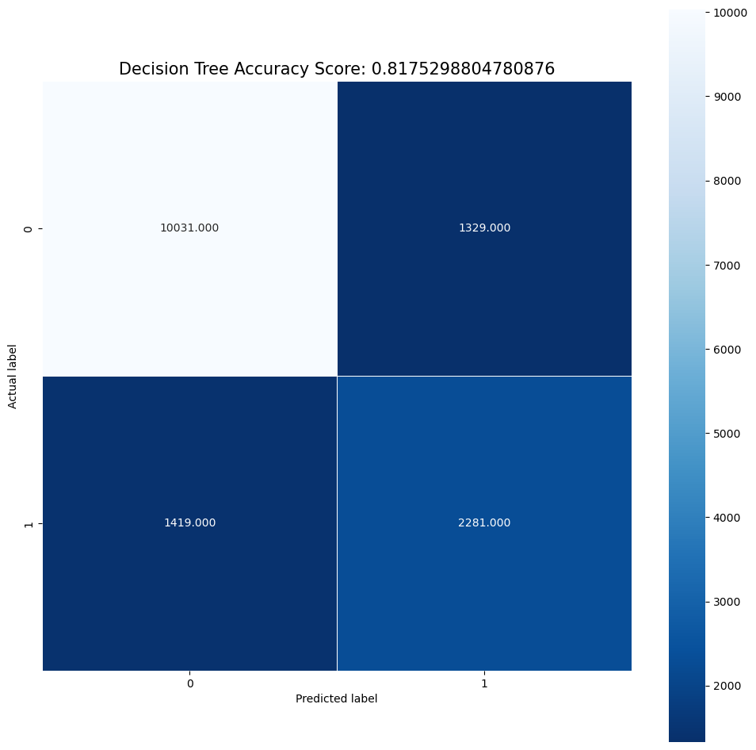

```python
plt.figure(figsize=(12,12))
sns.heatmap(tree_cm, annot=True, fmt=".3f", linewidths=.5, square = True, cmap = 'Blues_r');
plt.ylabel('Actual label');
plt.xlabel('Predicted label');
title = 'Decision Tree Accuracy Score: {0}'.format(tree_score)
plt.title(title, size = 15);
plt.show()
```

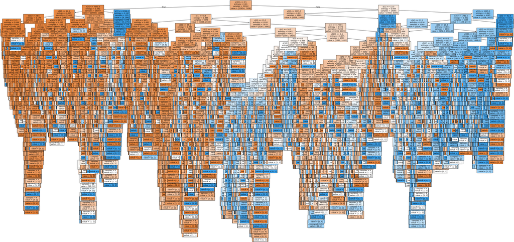

```python
fig, ax = plt.subplots(figsize=(50,24))
tree.plot_tree(clf, filled=True, fontsize=10)
plt.savefig('decision_tree', dpi=100)
plt.show()
```

### Cau8

```python
clf = tree.DecisionTreeClassifier(criterion="gini", random_state=0)
clf.fit(X_train, y_train)
```

```
DecisionTreeClassifier(random_state=0)
```

```python
tree_pred = clf.predict(X_test)

tree_score = metrics.accuracy_score(y_test, tree_pred)
print("Accuracy:", tree_score)
print("Report:", metrics.classification_report(y_test, tree_pred))
```

```
Accuracy: 0.8122841965471448
Report:               precision    recall  f1-score   support

       <=50K       0.87      0.88      0.88     11360
        >50K       0.62      0.60      0.61      3700

    accuracy                           0.81     15060
   macro avg       0.75      0.74      0.74     15060
weighted avg       0.81      0.81      0.81     15060
```

```python
tree_cm = metrics.confusion_matrix(y_test, tree_pred)
```

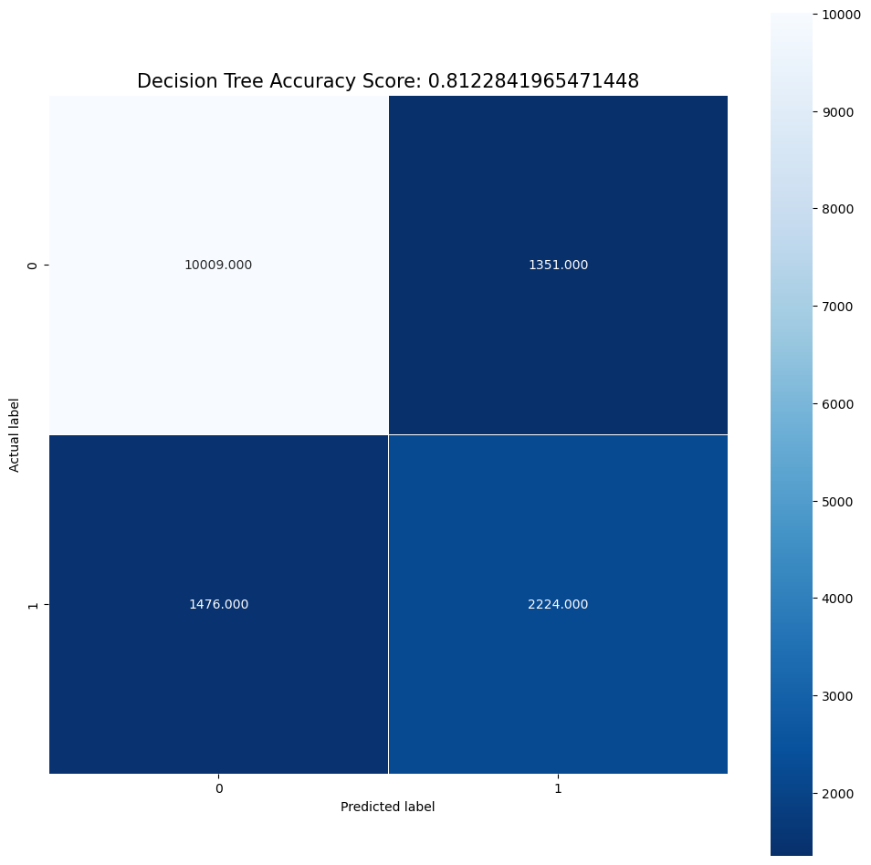

```python
plt.figure(figsize=(12,12))
sns.heatmap(tree_cm, annot=True, fmt=".3f", linewidths=.5, square = True, cmap = 'Blues_r');
plt.ylabel('Actual label');
plt.xlabel('Predicted label');
title = 'Decision Tree Accuracy Score: {0}'.format(tree_score)
plt.title(title, size = 15);
plt.show()
```

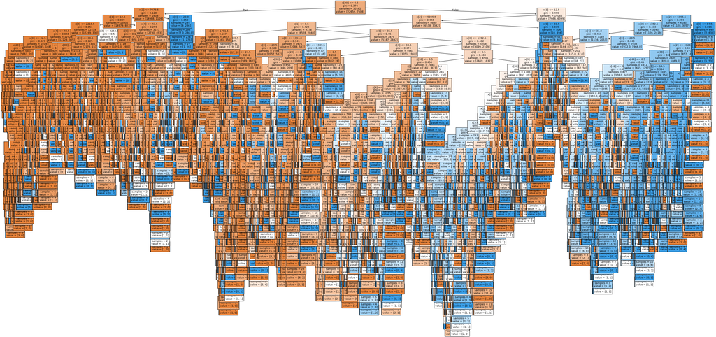

```python
fig, ax = plt.subplots(figsize=(50,24))
tree.plot_tree(clf, filled=True, fontsize=10)
plt.savefig('decision_tree', dpi=100)
plt.show()
```

### Cau9

```python
gnb = GaussianNB()
bayes_pred = gnb.fit(X_train, y_train).predict(X_test)

#Tinh toan cac gia tri cua mo hinh
bayes_score = metrics.accuracy_score(y_test, bayes_pred)
print("Accuracy:", bayes_score)
print("Report:", metrics.classification_report(y_test, bayes_pred))
```

```
Accuracy: 0.8029216467463479
Report:               precision    recall  f1-score   support

       <=50K       0.93      0.80      0.86     11360
        >50K       0.57      0.82      0.67      3700

    accuracy                           0.80     15060
   macro avg       0.75      0.81      0.76     15060
weighted avg       0.84      0.80      0.81     15060
```

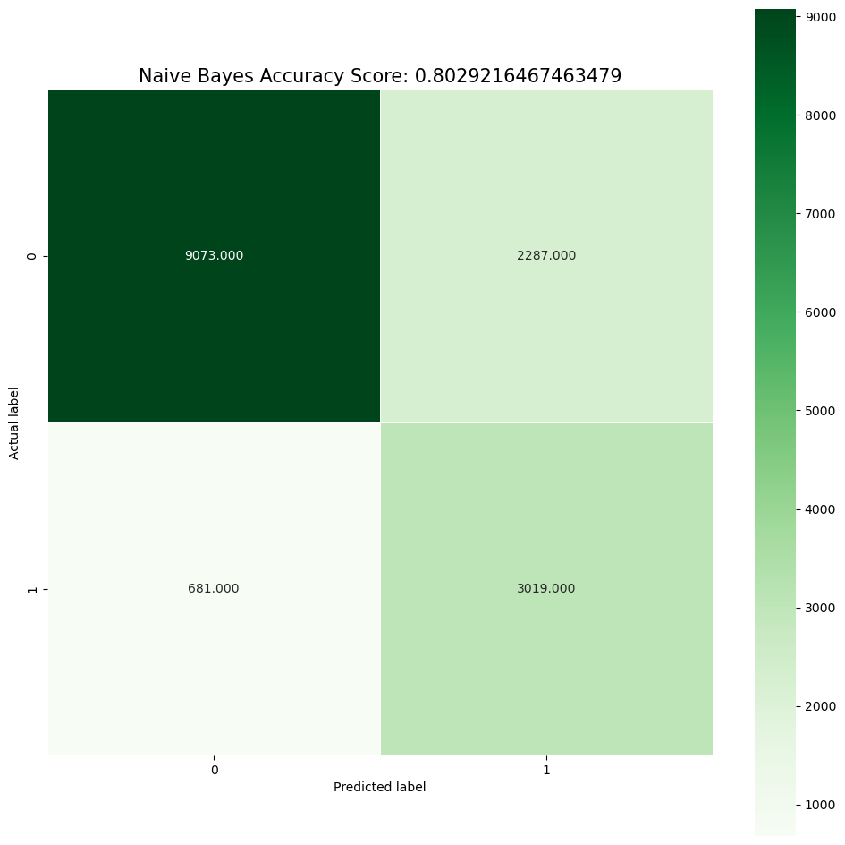

```python
bayes_cm = metrics.confusion_matrix(y_test, bayes_pred)
plt.figure(figsize=(12,12))
sns.heatmap(bayes_cm, annot=True, fmt=".3f", linewidths=.5, square = True, cmap = 'Greens');
plt.ylabel('Actual label');
plt.xlabel('Predicted label');
title = 'Naive Bayes Accuracy Score: {0}' .format(bayes_score)
plt.title(title, size = 15);
plt.show()
```

### Cau10: Danh gia va nhan xet

#### Nhận xét

##### Decision Tree với Entropy:

Độ chính xác: 81.75% Precision, recall và F1-score: Lớp <=50K (11360 mẫu): Precision = 0.88, Recall = 0.88, F1-score = 0.88 Lớp >50K (3700 mẫu): Precision = 0.63, Recall = 0.62, F1-score = 0.62 Độ chính xác của thuật toán đạt mức khá cao (81.75%). Lớp <=50K có độ chính xác và F1-score tốt hơn so với lớp >50K, nhưng điều này có thể do sự chênh lệch về số lượng mẫu giữa các lớp. => Thuật toán có khả năng phân loại tốt với lớp lớn <=50K, nhưng độ chính xác của lớp >50K vẫn còn cần cải thiện.

##### Decision Tree với Gini:

Độ chính xác: 81.23% Precision, recall và F1-score: Lớp <=50K (11360 mẫu): Precision = 0.87, Recall = 0.88, F1-score = 0.88 Lớp >50K (3700 mẫu): Precision = 0.62, Recall = 0.60, F1-score = 0.61 Thuật toán với Gini có độ chính xác tương đối gần với Entropy, tuy nhiên thấp hơn một chút (81.23%). => Gini có độ chính xác tốt ở lớp <=50K, nhưng vẫn gặp khó khăn trong việc phân loại chính xác lớp >50K.

##### Naive Bayes:

Độ chính xác: 80.29% Precision, recall và F1-score: Lớp <=50K (11360 mẫu): Precision = 0.93, Recall = 0.80, F1-score = 0.86 Lớp >50K (3700 mẫu): Precision = 0.57, Recall = 0.82, F1-score = 0.67 Thuật toán Naive Bayes có độ chính xác thấp nhất (80.29%), nhưng lại có đặc điểm khác biệt. Precision ở lớp <=50K cao nhất (0.93), trong khi Recall của lớp >50K khá cao (0.82), giúp cải thiện việc nhận diện lớp >50K.

#### Kết luận tổng quát

Decision Tree với Entropy là thuật toán tối ưu nhất trong trường hợp này với độ chính xác tổng thể cao nhất (81.75%) và F1-score tốt cho lớp lớn. Decision Tree với Gini có kết quả gần tương đương với Entropy nhưng thấp hơn một chút, phù hợp nếu ưu tiên về tốc độ. Naive Bayes có độ chính xác thấp nhất, nhưng có ưu điểm ở việc nhận diện lớp >50K với Recall cao hơn.

#### Trong trường hợp này thì thuật toán Entropy tốt hơn Gini và Naive Bayes